# Assignment6

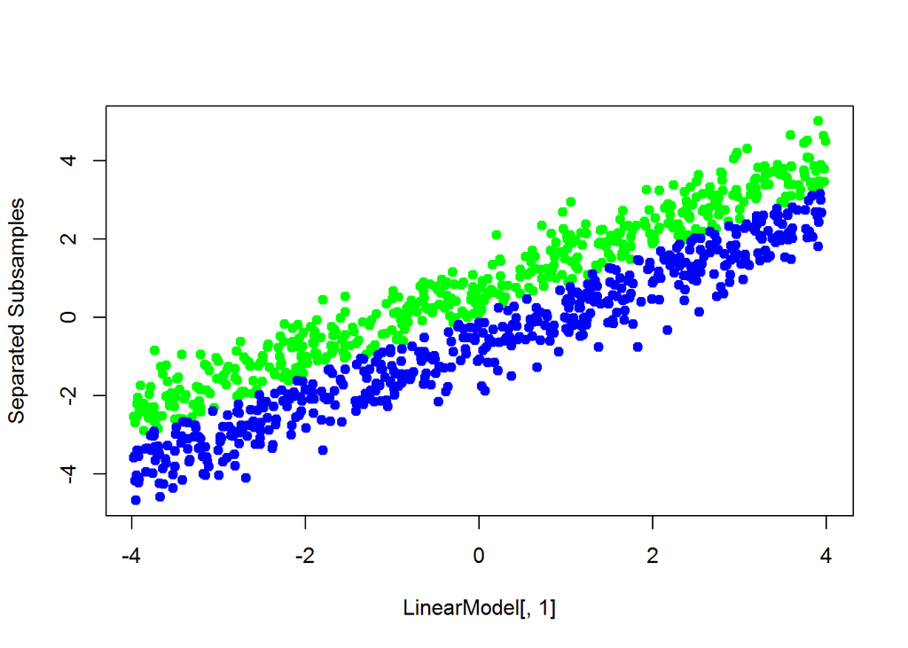

```r
# Plot the unscrambled subsamples
matplot(LinearModel[,1],cbind(LinearModel1.Recovered[,2],LinearModel2.Recovered[,2]), type="p",col=c("green","blue"),pch=19,ylab="Separated Subsamples")
```

Now estimate the linear models for the subsamples.

```r
LinearModel1.Recovered.lm<-lm(LinearModel1.Recovered[,2]~LinearModel1.Recovered[,1])
LinearModel2.Recovered.lm<-lm(LinearModel2.Recovered[,2]~LinearModel2.Recovered[,1])
```

Compare the results of fitting of the first recovered linear model

```r
summary(LinearModel1.Recovered.lm)
```

```
##
## Call:
## lm(formula = LinearModel1.Recovered[, 2] ~ LinearModel1.Recovered[,
##     1])
##
## Residuals:
##      Min       1Q   Median       3Q      Max
## -0.70777 -0.33381 -0.04006  0.27395  1.39762
##
## Coefficients:
##                             Estimate Std. Error t value Pr(>|t|)
## (Intercept)                 0.759904   0.019251   39.47   <2e-16 ***
## LinearModel1.Recovered[, 1] 0.803360   0.008292   96.88   <2e-16 ***
## ---
## Signif. codes:  0 '***' 0.001 '**' 0.01 '*' 0.05 '.' 0.1 ' ' 1
##
## Residual standard error: 0.4256 on 487 degrees of freedom
##   (511 observations deleted due to missingness)
## Multiple R-squared:  0.9507, Adjusted R-squared:  0.9506
## F-statistic:  9386 on 1 and 487 DF,  p-value: < 2.2e-16
```

and the second recovered linear model:

```r
summary(LinearModel2.Recovered.lm)
```

```
##
## Call:
## lm(formula = LinearModel2.Recovered[, 2] ~ LinearModel2.Recovered[,
##     1])
##
## Residuals:
##      Min       1Q   Median       3Q      Max
## -1.57919 -0.29823  0.02554  0.36264  0.79212
##
## Coefficients:
##                              Estimate Std. Error t value Pr(>|t|)
## (Intercept)                 -0.666713   0.020242  -32.94   <2e-16 ***
## LinearModel2.Recovered[, 1]  0.811196   0.008643   93.86   <2e-16 ***
## ---
## Signif. codes:  0 '***' 0.001 '**' 0.01 '*' 0.05 '.' 0.1 ' ' 1
##
## Residual standard error: 0.457 on 509 degrees of freedom
##   (489 observations deleted due to missingness)
## Multiple R-squared:  0.9454, Adjusted R-squared:  0.9453
## F-statistic:  8809 on 1 and 509 DF,  p-value: < 2.2e-16
```

*Compare the summaries of the mix with the summary of the single linear model fit.*

Plot the residuals estimated by a single linear model and the residuals of the unscrambled mix. Estimate standard deviations of the two samples of residuals:

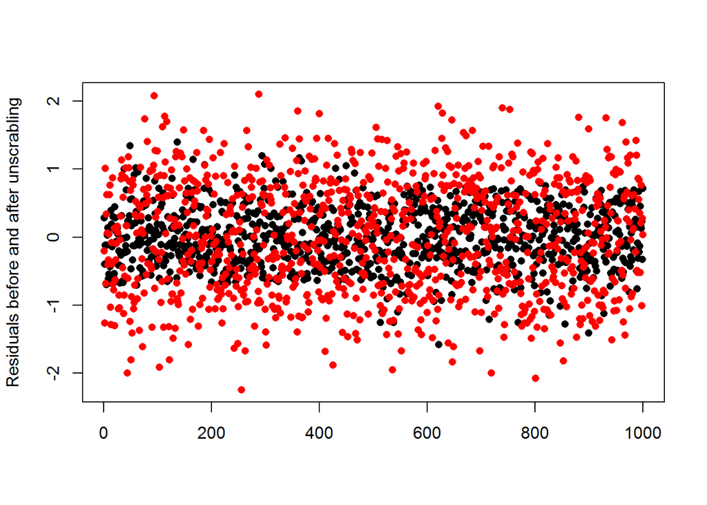

```r
# Plot residuals
Residuals.Comparison<-cbind(Unscrambled.residuals=c(summary(LinearModel1.Recovered.lm)$residuals,summary(LinearModel2.Recovered.lm)$residuals),Single.Model.residuals=EstimatedResiduals)
matplot(Residuals.Comparison,type="p",pch=16,ylab="Residuals before and after unscrabling")
```

```r
# Estimate standard deviations
apply(Residuals.Comparison,2,sd)
```

```
##  Unscrambled.residuals Single.Model.residuals
##              0.4412653              0.8384730
```

Conclusion

How the sample was mixed? With what probability? Was the probability significantly different from 0.5? What were the parameters of mixed models? How much we reduced variance of residuals by separating the models?

Unscrumbling using logistic model gives not equivalent, but not significantly different results from our first heuristic approach.

## 2. Check Assumptions of Linear Model.

```r
assignmentData<-read.csv(file=paste(datapath,"AssignmentData.csv",sep="/"),
                         header = TRUE,sep=",")

head(assignmentData)
```

```
##         Input    Output
## 1 -2.23464884 -3.498104
## 2  0.78746123  0.771090
## 3  1.99680464  2.554582
## 4 -0.15115047 -3.547054
## 5  0.09096086 -3.244699
## 6  2.57175934  3.036760
```

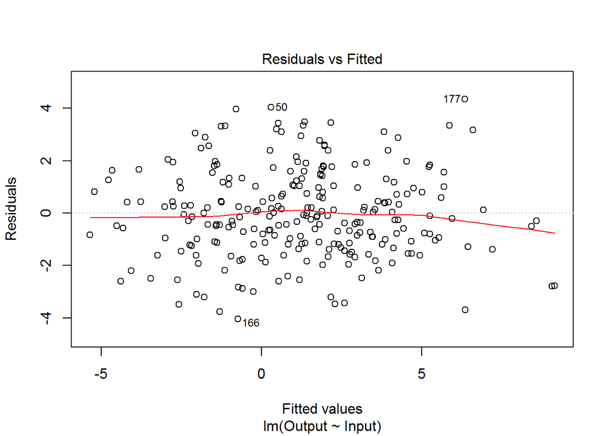

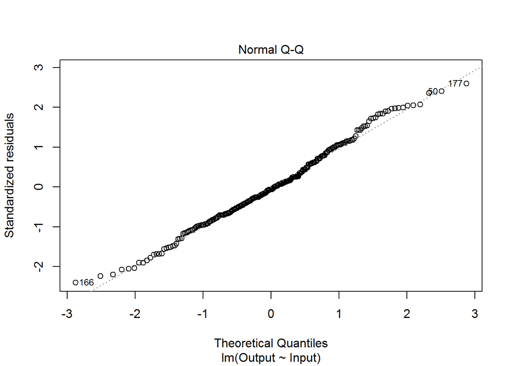

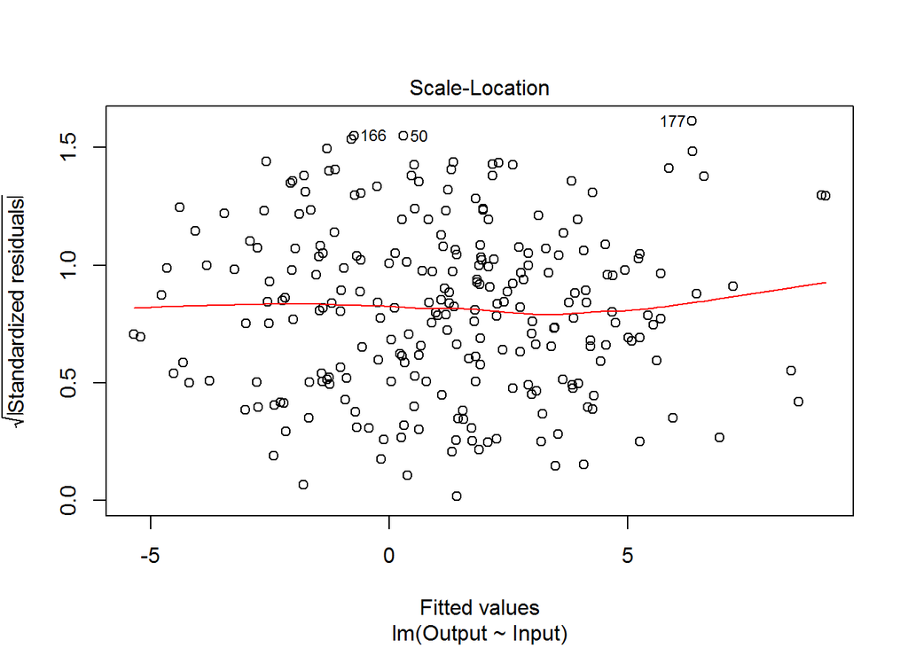

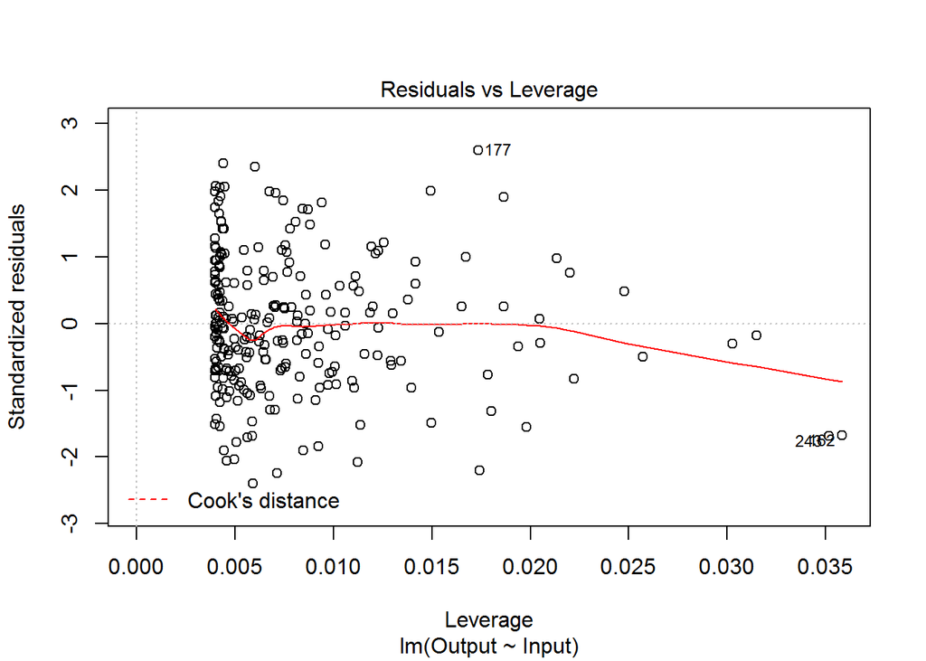

```r
lm2 <- lm(Output ~ Input, data = assignmentData)

plot(lm2)
```

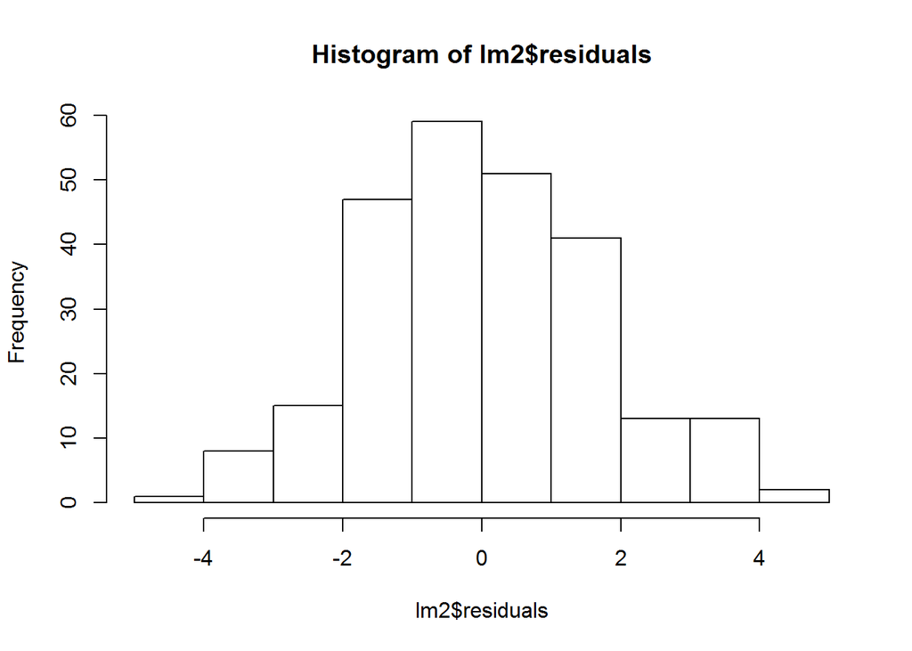

```r
hist(lm2$residuals)
## Normal
hist(lm2$residuals)
```

```r
ks.test(lm2$residuals,pnorm, alternative = "two.sided")
```

```
##
##  One-sample Kolmogorov-Smirnov test
##
## data:  lm2$residuals
## D = 0.13888, p-value = 0.0001296
## alternative hypothesis: two-sided
```

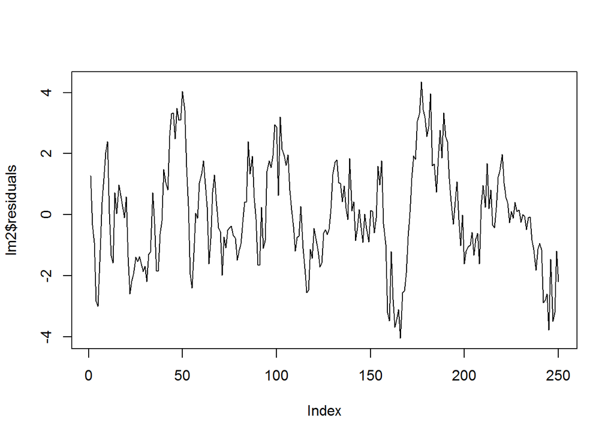

```r
## IID
plot(lm2$residuals, type = "l")
```

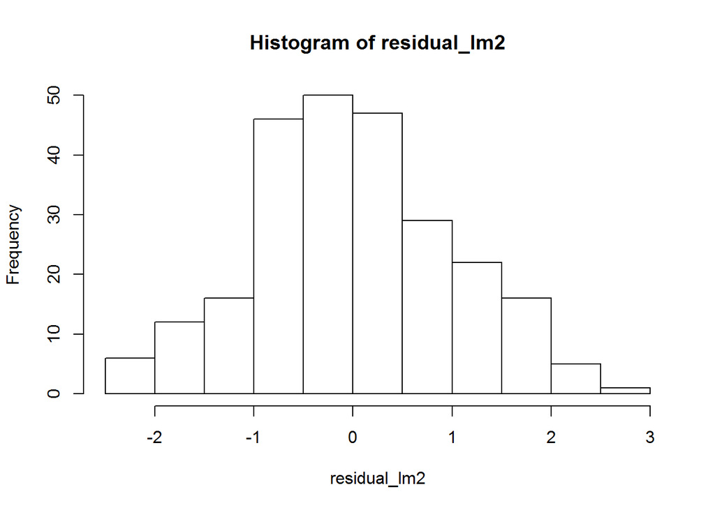

```r
residual_lm2  <- lm2$residuals
residual_lm2 <- (residual_lm2 - mean(residual_lm2))/sd(residual_lm2)
hist(residual_lm2)
```

```r
qnorm(0)
```

```
## [1] -Inf
```

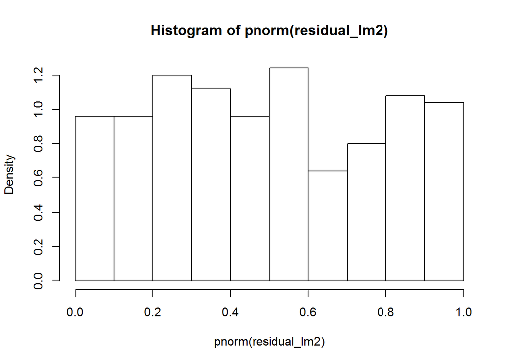

```r
Sample.histogram <- hist(pnorm(residual_lm2),freq = FALSE)
```

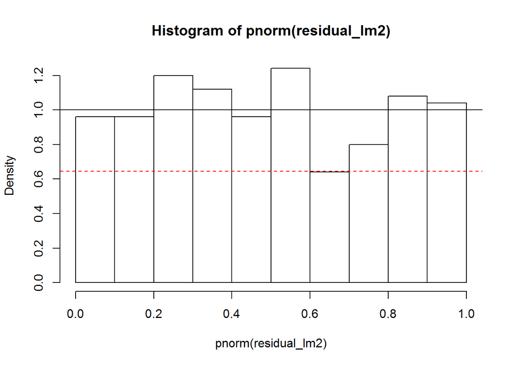

```r
Sample.histogram.mean <- mean(Sample.histogram$density)
Sample.histogram.sd <- sd(Sample.histogram$density)
plot(Sample.histogram,freq=FALSE)
abline(h=Sample.histogram.mean)
abline(h=Sample.histogram.mean+1.96*Sample.histogram.sd,col="red",lty=2)
abline(h=Sample.histogram.mean-1.96*Sample.histogram.sd,col="red",lty=2)
```

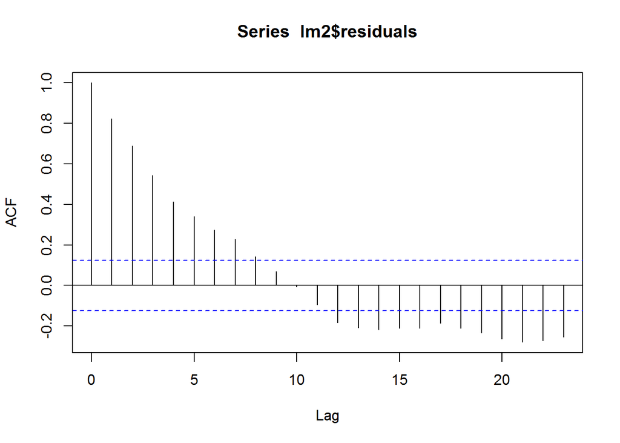

```r
## Autocorrelation function
acf（lm2$residuals)
```

```r
## Autocorrelation lag 1

lag1 <- residual_lm2[2:length(residual_lm2)]
Origin <- residual_lm2[1:(length(residual_lm2)-1)]
summary(lm(lag1 ~ Origin))
```

```
##
## Call:
## lm(formula = lag1 ~ Origin)
##
## Residuals:
##      Min       1Q   Median       3Q      Max
## -1.41745 -0.33031 -0.03701  0.39328  1.59581
##
## Coefficients:
##             Estimate Std. Error t value Pr(>|t|)
## (Intercept) -0.00735    0.03564  -0.206    0.837
## Origin       0.82980    0.03576  23.201   <2e-16 ***
## ---
## Signif. codes:  0 '***' 0.001 '**' 0.01 '*' 0.05 '.' 0.1 ' ' 1
##
## Residual standard error: 0.5624 on 247 degrees of freedom
## Multiple R-squared:  0.6855, Adjusted R-squared:  0.6842
## F-statistic: 538.3 on 1 and 247 DF,  p-value: < 2.2e-16
```

Are main assumptions of linear model satisfied?

- Gaussian assumption
- IID assumption
- Autocorrelation function
- Autocorrelation with lag 1 Hint. You might find assignment from week 2 useful.

## 3.Test

```r
dataPath <- getwd()
train_dat <- read.table(paste(dataPath,'Test_Sample_Train.csv',sep = '/'), header=TRUE)
main_dat <- read.table(paste(dataPath,'Test_Sample_Test.csv',sep = '/'), header=TRUE)
head(train_dat)
```

```
##       Output      Input Selection.Sequence
## 1  1.4387928 -2.0157874                  1
## 2  1.6941290 -2.3188295                  1
## 3 -1.9842629  3.9696742                  0
## 4 -0.1535422  1.6915972                  1
## 5 -0.3921057 -0.2499193                  0
## 6 -1.2587765  1.9634230                  0
```

```r
lm <- lm(Output ~ Input, data = train_dat )
residual_lm <- lm$residuals

lm_main <- lm(Output ~ Input, data = main_dat)
residual_main <- lm_main$residuals

Logistic.Model.Data <- data.frame(Logistic.Output = train_dat$Selection.Sequence, Logistic.Input = residual_lm)
LinearModel.Training.Logistic<-glm(Logistic.Output~Logistic.Input,data=Logistic.Model.Data,
                                   family=binomial(link=logit))
summary(LinearModel.Training.Logistic)
```

```
##
## Call:
## glm(formula = Logistic.Output ~ Logistic.Input, family = binomial(link = logit),
##     data = Logistic.Model.Data)
##
## Deviance Residuals:
##      Min        1Q    Median        3Q       Max
## -1.88705  -0.10860   0.00774   0.08390   2.08068
##
## Coefficients:
##                Estimate Std. Error z value Pr(>|z|)
## (Intercept)      1.4227     0.4485   3.172  0.00151 **
## Logistic.Input  13.1899     2.3470   5.620 1.91e-08 ***
## ---
## Signif. codes:  0 '***' 0.001 '**' 0.01 '*' 0.05 '.' 0.1 ' ' 1
##
## (Dispersion parameter for binomial family taken to be 1)
##
##     Null deviance: 273.869  on 199  degrees of freedom
## Residual deviance:  55.687  on 198  degrees of freedom
## AIC: 59.687
##
## Number of Fisher Scoring iterations: 8
```

```r
Unscrambling.Sequence.Logistic<-(predict(LinearModel.Training.Logistic,
                                         newdata=data.frame(Logistic.Output=residual_main,
                                                            Logistic.Input=residual_main),type="response")>.5)*1

res <- list(Unscrambling.Sequence.Logistic =  Unscrambling.Sequence.Logistic)
write.table(res, file = paste(dataPath,'result.csv',sep = '/'), row.names = F)
```